# Reproducible Data - Project 1

```r
library(readr)
library(readr)
activity <- read_csv("C:/Users/Charb/OneDrive/Desktop/R training/Reproducible_Research/repdata_data_activity/activity.csv")
```

## What is the mean total number of steps taken per day?

1. I calculate the total number of steps taken per day:

```r
library(plyr)
library(dplyr)
steps_per_day <- activity %>%
  group_by(date) %>%
  summarise(total = sum(steps, na.rm = TRUE))
```

2. I create a histogram of the distribution of the number of steps taken

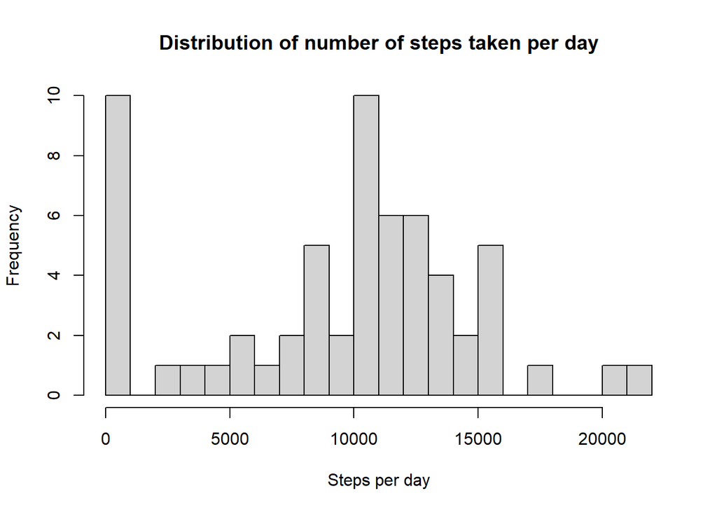

```r
hist(steps_per_day$total, breaks = 20, xlab = "Steps per day", main =
       "Distribution of number of steps taken per day")
```

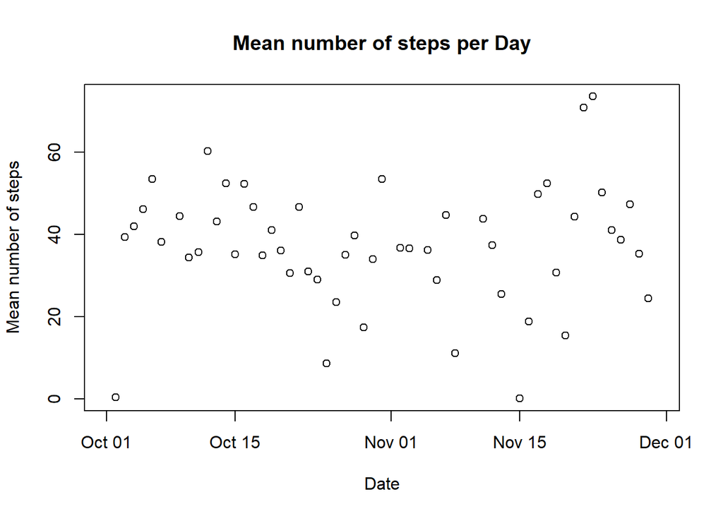

```r
mean_per_day <- activity %>%
  group_by(date) %>%
  summarise(total = mean(steps, na.rm = TRUE))

plot(mean_per_day$date, mean_per_day$total, ylab="Mean number of steps",
     xlab="Date", main = "Mean number of steps per Day")
```

```r
median_per_day <- activity %>%
  group_by(date) %>%
  summarise(total = median(steps, na.rm = TRUE))
```

## What is the average daily activity pattern?

1. I make a time plot divided by the 5 minute intervals

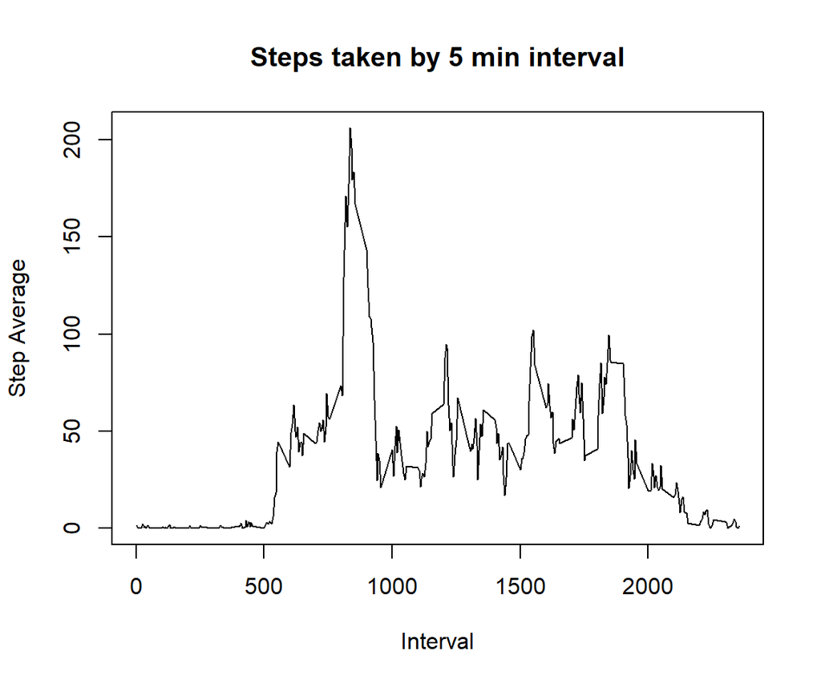

```r
mean_per_interval <- activity %>%
  group_by(interval) %>%
  summarise(total = mean(steps, na.rm = TRUE))

plot(mean_per_interval$interval, mean_per_interval$total, type ="l",
     xlab="Interval", ylab="Step Average", main = "Steps taken by 5 min interval")
```

2. The interval that has the highest number of steps is :

```r
max_per_interval <- activity %>%
  group_by(interval) %>%
  summarise(total = sum(steps, na.rm = TRUE)) %>%
  summarise (max = interval[which.max(total)])
max_per_interval[[1,1]]
```

```
## [1] 835
```

The interval number 835 contains the most total number of steps taken

## Imputing missing values

1. The total number of NAs in the data set is:

```r
sum(is.na(activity$steps))
```

```
## [1] 2304
```

2. A strategy to get rid of the missing data. I’ll use the mean by interval

```r
activity_filled <- activity %>%
  left_join(mean_per_interval, by = "interval") %>%
  mutate(steps = ifelse(is.na(steps), total, steps)) %>%
  select(-total)
```

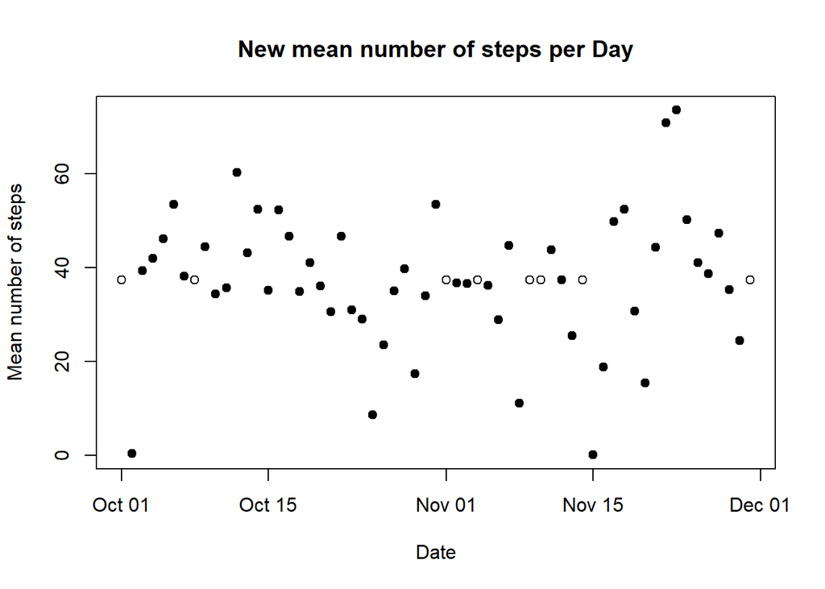

```r
new_mean_per_day <- activity_filled %>%
  group_by(date) %>%
  summarise(total = mean(steps, na.rm = TRUE))

plot(new_mean_per_day$date, new_mean_per_day$total, ylab="Mean number of steps",
     xlab="Date", main = "New mean number of steps per Day")
points(mean_per_day$date, mean_per_day$total, pch = 19)
```

There was not a big change for the mean. Only the points in white are those that changed

```r
new_median_per_day <- activity_filled %>%
  group_by(date) %>%
  summarise(total = median(steps, na.rm = TRUE))
```

## Are there differences in activity patterns between weekdays and weekends?

1. Creating the factor “weekdays” and “weekends”

```r
activity_filled <- activity_filled %>%
  mutate(Day = weekdays(date)) %>%
  mutate(Day = if_else(Day %in% c("Saturday", "Sunday"), "Weekend", "Weekday"))
```

2. Making a plot containing the average steps taken on weekdays vs weekends

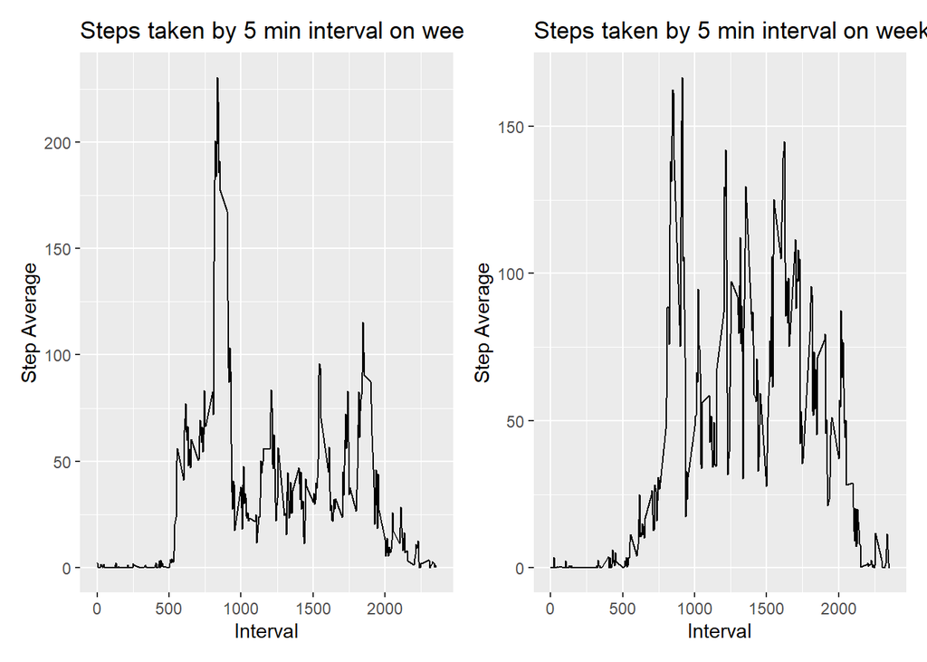

```r
mean_week_day <- activity_filled %>%
  group_by(Day, interval) %>%
  summarise(steps = mean(steps), .groups = "keep")

library(ggplot2)
library(patchwork)
p1 <- ggplot(mean_week_day[mean_week_day$Day == "Weekday", ], aes(x = interval, y = steps)) +
  geom_line() +
  labs(x = "Interval", y = "Step Average",
       title = "Steps taken by 5 min interval on weekdays")

# Plot for Weekends
p2 <- ggplot(mean_week_day[mean_week_day$Day == "Weekend", ], aes(x = interval, y = steps)) +
  geom_line() +
  labs(x = "Interval", y = "Step Average",
       title = "Steps taken by 5 min interval on weekends")

p1 + p2 + plot_layout(ncol = 2)
```